# Homework 04

# Overview

In this homework assignment, you will explore, analyze and model a dataset containing approximately 8000 records representing a customer at an auto insurance company. Each record has two response variables. The first responsevariable, TARGET_FLAG, is a 1 or a 0. A “1” means that the person was in a car crash. A zero means that the person was not in a car crash.The second responsevariable is TARGET_AMT. This value is zero if the person did not crash their car. But if they did crash their car, this number will be a value greater than zero.

# Data Exploration

We will explore both training and evaluation data as the first step in the data exploration.

```
## [1] "Dimension of training set:   Number of rows: 8161, Number of cols: 26"
```

```
##   INDEX TARGET_FLAG TARGET_AMT KIDSDRIV AGE HOMEKIDS YOJ   INCOME PARENT1
## 1     1           0          0        0  60        0  11  $67,349      No
## 2     2           0          0        0  43        0  11  $91,449      No
## 3     4           0          0        0  35        1  10  $16,039      No
## 4     5           0          0        0  51        0  14               No
## 5     6           0          0        0  50        0  NA $114,986      No
## 6     7           1       2946        0  34        1  12 $125,301     Yes
##   HOME_VAL MSTATUS SEX     EDUCATION           JOB TRAVTIME    CAR_USE BLUEBOOK
## 1       $0    z_No   M           PhD  Professional       14    Private  $14,230
## 2 $257,252    z_No   M z_High School z_Blue Collar       22 Commercial  $14,940
## 3 $124,191     Yes z_F z_High School      Clerical        5    Private   $4,010
## 4 $306,251     Yes   M  <High School z_Blue Collar       32    Private  $15,440
## 5 $243,925     Yes z_F           PhD        Doctor       36    Private  $18,000
## 6       $0    z_No z_F     Bachelors z_Blue Collar       46 Commercial  $17,430
##   TIF   CAR_TYPE RED_CAR OLDCLAIM CLM_FREQ REVOKED MVR_PTS CAR_AGE
## 1  11    Minivan     yes   $4,461        2      No       3      18
## 2   1    Minivan     yes       $0        0      No       0       1
## 3   4      z_SUV      no  $38,690        2      No       3      10
## 4   7    Minivan     yes       $0        0      No       0       6
## 5   1      z_SUV      no  $19,217        2     Yes       3      17
## 6   1 Sports Car      no       $0        0      No       0       7
##            URBANICITY
## 1 Highly Urban/ Urban
## 2 Highly Urban/ Urban
## 3 Highly Urban/ Urban
## 4 Highly Urban/ Urban
## 5 Highly Urban/ Urban
## 6 Highly Urban/ Urban
```

```
## [1] "Structure of training data set:"
```

```
## 'data.frame':    8161 obs. of  26 variables:
##  $ INDEX      : int  1 2 4 5 6 7 8 11 12 13 ...
##  $ TARGET_FLAG: int  0 0 0 0 0 1 0 1 1 0 ...
##  $ TARGET_AMT : num  0 0 0 0 0 ...
##  $ KIDSDRIV   : int  0 0 0 0 0 0 0 1 0 0 ...
##  $ AGE        : int  60 43 35 51 50 34 54 37 34 50 ...
##  $ HOMEKIDS   : int  0 0 1 0 0 1 0 2 0 0 ...
##  $ YOJ        : int  11 11 10 14 NA 12 NA NA 10 7 ...
##  $ INCOME     : chr  "$67,349" "$91,449" "$16,039" "" ...
##  $ PARENT1    : chr  "No" "No" "No" "No" ...
##  $ HOME_VAL   : chr  "$0" "$257,252" "$124,191" "$306,251" ...
##  $ MSTATUS    : chr  "z_No" "z_No" "Yes" "Yes" ...
##  $ SEX        : chr  "M" "M" "z_F" "M" ...
##  $ EDUCATION  : chr  "PhD" "z_High School" "z_High School" "<High School" ...
##  $ JOB        : chr  "Professional" "z_Blue Collar" "Clerical" "z_Blue Collar" ...
##  $ TRAVTIME   : int  14 22 5 32 36 46 33 44 34 48 ...
##  $ CAR_USE    : chr  "Private" "Commercial" "Private" "Private" ...
##  $ BLUEBOOK   : chr  "$14,230" "$14,940" "$4,010" "$15,440" ...
##  $ TIF        : int  11 1 4 7 1 1 1 1 1 7 ...
##  $ CAR_TYPE   : chr  "Minivan" "Minivan" "z_SUV" "Minivan" ...
##  $ RED_CAR    : chr  "yes" "yes" "no" "yes" ...
##  $ OLDCLAIM   : chr  "$4,461" "$0" "$38,690" "$0" ...
##  $ CLM_FREQ   : int  2 0 2 0 2 0 0 1 0 0 ...
##  $ REVOKED    : chr  "No" "No" "No" "No" ...
##  $ MVR_PTS    : int  3 0 3 0 3 0 0 10 0 1 ...
##  $ CAR_AGE    : int  18 1 10 6 17 7 1 7 1 17 ...
##  $ URBANICITY : chr  "Highly Urban/ Urban" "Highly Urban/ Urban" "Highly Urban/ Urban" "Highly Urban/ Urban" ...
```

Checking for NA.

```
## [1] TRUE
```

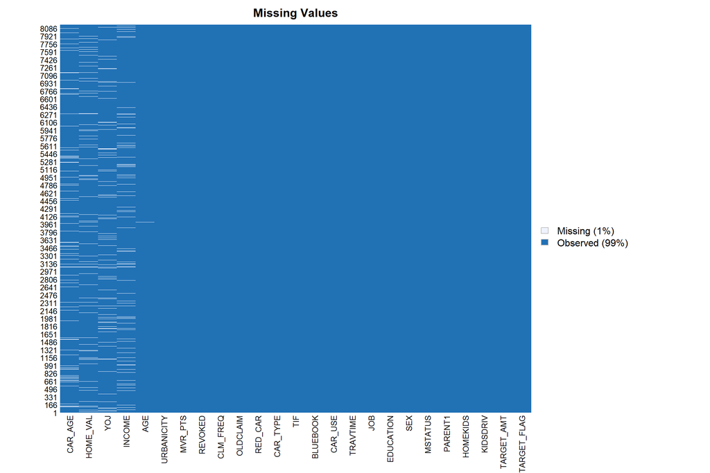

There are NA in our data, We will impute NA using mice().

Rechecking for NA after imputation.

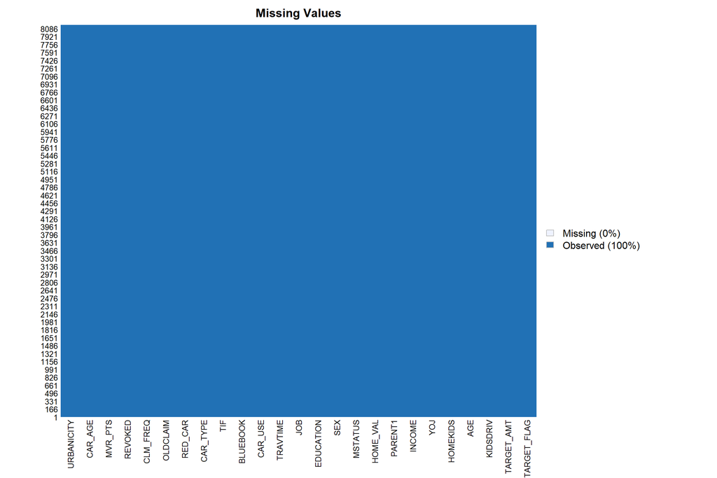

We observe that NA were removed.

Here, We’ll further explore the data. Firsr, We’ll look at min, 1st quartile, median, mean, 2nd quartile, max etc.

|  | TARGET_FLAG | TARGET_AMT | KIDSDRIV | AGE | HOMEKIDS | YOJ | INCOME | PARENT1 | HOME_VAL | MSTATUS | SEX | EDUCATION | JOB | TRAVTIME | CAR_USE | BLUEBOOK | TIF | CAR_TYPE | RED_CAR | OLDCLAIM | CLM_FREQ | REVOKED | MVR_PTS | CAR_AGE | URBANICITY |
| --- | --- | --- | --- | --- | --- | --- | --- | --- | --- | --- | --- | --- | --- | --- | --- | --- | --- | --- | --- | --- | --- | --- | --- | --- | --- |
|  | Min. :0.0000 | Min. : 0 | Min. :0.0000 | Min. :16.00 | Min. :0.0000 | Min. : 0.00 | Min. : 0 | Length:8161 | Min. : 0 | Length:8161 | Length:8161 | Length:8161 | Length:8161 | Min. : 5.00 | Length:8161 | Min. : 1500 | Min. : 1.000 | Length:8161 | Length:8161 | Min. : 0 | Min. :0.0000 | Length:8161 | Min. : 0.000 | Min. :-3.000 | Length:8161 |
|  | 1st Qu.:0.0000 | 1st Qu.: 0 | 1st Qu.:0.0000 | 1st Qu.:39.00 | 1st Qu.:0.0000 | 1st Qu.: 9.00 | 1st Qu.: 28088 | Class :character | 1st Qu.: 0 | Class :character | Class :character | Class :character | Class :character | 1st Qu.: 22.00 | Class :character | 1st Qu.: 9280 | 1st Qu.: 1.000 | Class :character | Class :character | 1st Qu.: 0 | 1st Qu.:0.0000 | Class :character | 1st Qu.: 0.000 | 1st Qu.: 1.000 | Class :character |
|  | Median :0.0000 | Median : 0 | Median :0.0000 | Median :45.00 | Median :0.0000 | Median :11.00 | Median : 53899 | Mode :character | Median :160699 | Mode :character | Mode :character | Mode :character | Mode :character | Median : 33.00 | Mode :character | Median :14440 | Median : 4.000 | Mode :character | Mode :character | Median : 0 | Median :0.0000 | Mode :character | Median : 1.000 | Median : 8.000 | Mode :character |
|  | Mean :0.2638 | Mean : 1504 | Mean :0.1711 | Mean :44.78 | Mean :0.7212 | Mean :10.52 | Mean : 61719 | NA | Mean :154533 | NA | NA | NA | NA | Mean : 33.49 | NA | Mean :15710 | Mean : 5.351 | NA | NA | Mean : 4037 | Mean :0.7986 | NA | Mean : 1.696 | Mean : 8.329 | NA |
|  | 3rd Qu.:1.0000 | 3rd Qu.: 1036 | 3rd Qu.:0.0000 | 3rd Qu.:51.00 | 3rd Qu.:1.0000 | 3rd Qu.:13.00 | 3rd Qu.: 85596 | NA | 3rd Qu.:238115 | NA | NA | NA | NA | 3rd Qu.: 44.00 | NA | 3rd Qu.:20850 | 3rd Qu.: 7.000 | NA | NA | 3rd Qu.: 4636 | 3rd Qu.:2.0000 | NA | 3rd Qu.: 3.000 | 3rd Qu.:12.000 | NA |
|  | Max. :1.0000 | Max. :107586 | Max. :4.0000 | Max. :81.00 | Max. :5.0000 | Max. :23.00 | Max. :367030 | NA | Max. :885282 | NA | NA | NA | NA | Max. :142.00 | NA | Max. :69740 | Max. :25.000 | NA | NA | Max. :57037 | Max. :5.0000 | NA | Max. :13.000 | Max. :28.000 | NA |

## Data reordering

For downstream analysis, we’ll reorder the columns into categorical, numeric and target.

## Boxplots

First look at the boxplots.

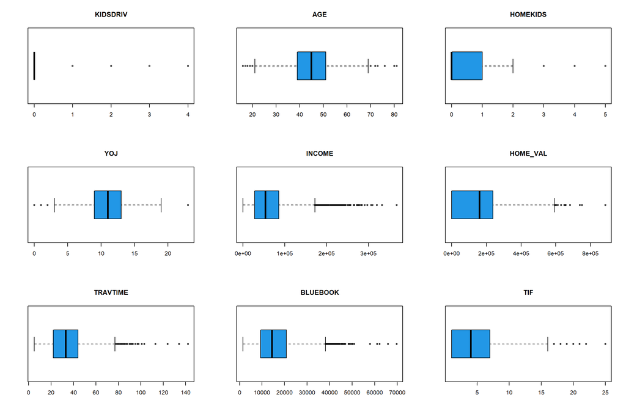

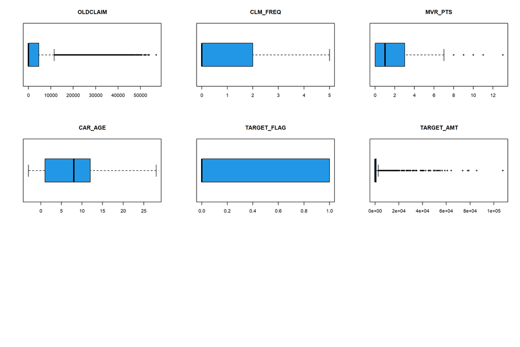

The boxplots show that some of the variables have outliers in them. So, we’ll cap them.

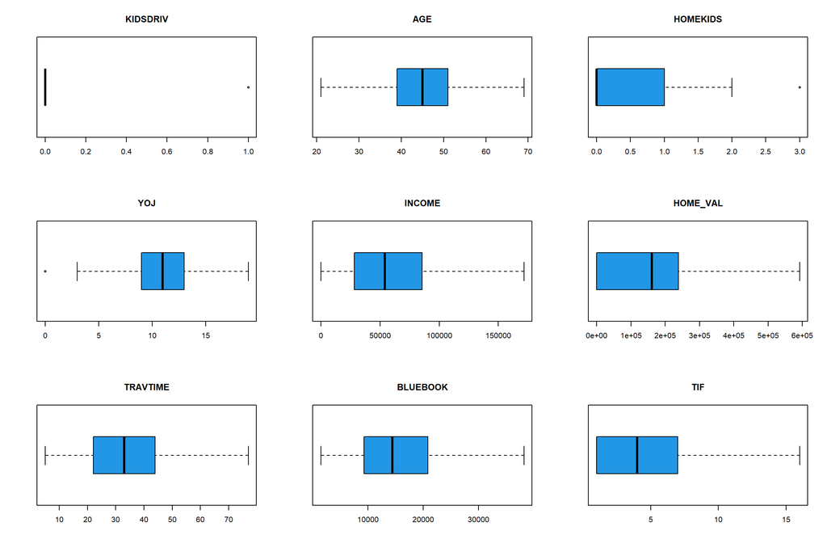

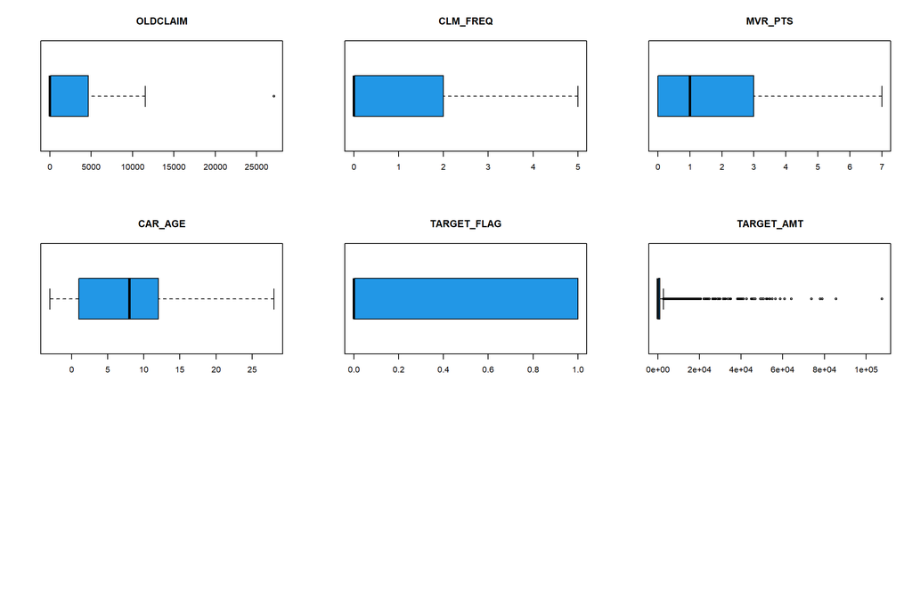

The fields AGE, HOMEKIDS, INCOME, HOME_VAL, TRVTIME, BLUEBOOK, TIF, CLM_FREQ, MVR_PTS, CAR_AGE have higher variance. We will ignore the boxplots for TARGET_FLAG and TARGET_AMT here.

## Histograms

We will see how the data is distributed (numeric fields) using histrogram.

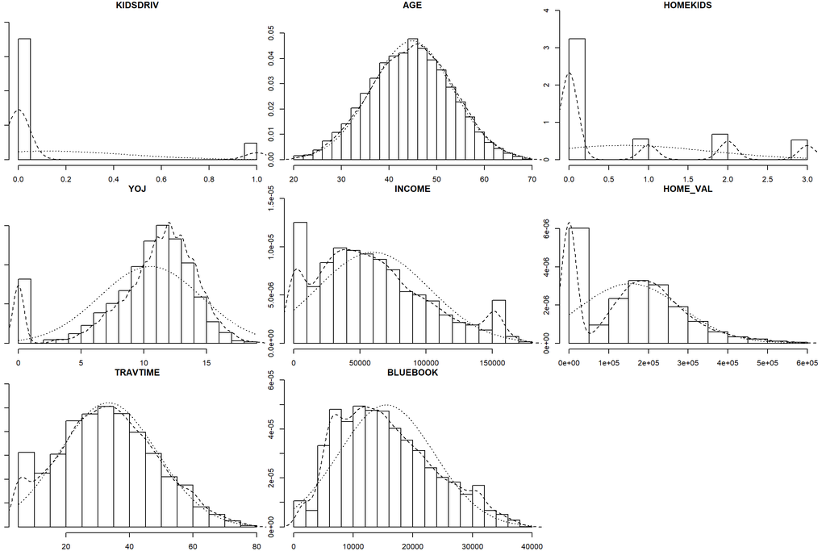

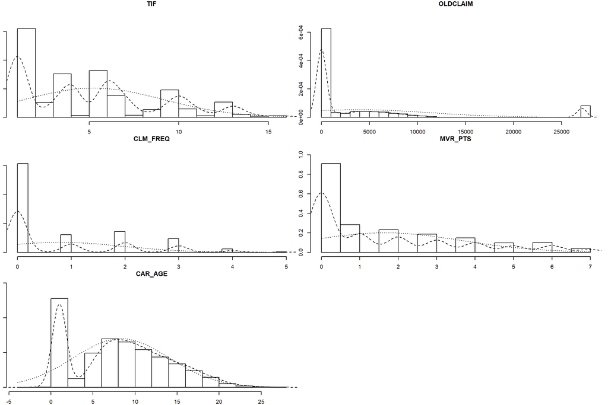

## Categorical variables

Now, let’s explore the Categorical variables.

```
## PARENT1:
```

```
##
##   No  Yes
## 7084 1077
```

```
## MSTATUS:
```

```
##
##   No  Yes
## 3267 4894
```

```
## SEX:
```

```
##
##    F    M
## 4375 3786
```

```
## EDUCATION:
```

```
##
## <High School    Bachelors  High School      Masters          PhD
##         1203         2242         2330         1658          728
```

```
## JOB:
```

```
##
##               Blue Collar     Clerical       Doctor   Home Maker       Lawyer
##          526         1825         1271          246          641          835
##      Manager Professional      Student
##          988         1117          712
```

```
## CAR_USE:
```

```
##
## Commercial    Private
##       3029       5132
```

```
## CAR_TYPE:
```

```
##
##     Minivan Panel Truck      Pickup  Sports Car         SUV         Van
##        2145         676        1389         907        2294         750
```

```
## RED_CAR:
```

```
##
##   no  yes
## 5783 2378
```

```
## REVOKED:
```

```
##
##   No  Yes
## 7161 1000
```

```
## URBANICITY:
```

```
##
## Highly Rural/ Rural Highly Urban/ Urban
##                1669                6492
```

There are 526 rows empty in JOB column. So, we’ll impute them with “Unknown”.

```
## JOB:
```

```
##
##  Blue Collar     Clerical       Doctor   Home Maker       Lawyer      Manager
##         1825         1271          246          641          835          988
## Professional      Student      Unknown
##         1117          712          526
```

## Correlations

At this point the data is prepared. So, we’ll explore the top correlated variables.

There are 25 variables, among which 15 are numeric and 10 are non-categorical. In order to find the top correlated variables, we’ll give numerical values to the correlated variables.

|  | Top Correlated Variables TARGET_FLAG | Top Correlated Variables TARGET_AMT |
| --- | --- | --- |
| TARGET_FLAG | 1.0000000 | 1.0000000 |
| TARGET_AMT | 0.8334240 | 0.8334240 |
| URBANICITY | 0.2242509 | 0.1904945 |
| CLM_FREQ | 0.2161961 | 0.1869848 |
| MVR_PTS | 0.2075451 | 0.1741927 |
| OLDCLAIM | 0.2004106 | 0.1652881 |
| PARENT1 | 0.1576222 | 0.1359305 |
| REVOKED | 0.1519391 | 0.1263285 |
| HOMEKIDS | 0.1175903 | 0.1014967 |
| KIDSDRIV | 0.1036217 | 0.0863553 |
| CAR_TYPE | 0.1035765 | 0.0827170 |
| TRAVTIME | 0.0550685 | 0.0440349 |
| RED_CAR | -0.0069473 | 0.0005877 |
| SEX | -0.0210786 | -0.0088270 |
| JOB | -0.0669944 | -0.0509930 |
| YOJ | -0.0678665 | -0.0512803 |
| EDUCATION | -0.0734429 | -0.0532620 |
| TIF | -0.0818308 | -0.0690666 |
| CAR_AGE | -0.1025965 | -0.0712728 |
| AGE | -0.1041577 | -0.0802102 |
| BLUEBOOK | -0.1100800 | -0.0820739 |
| MSTATUS | -0.1351248 | -0.1209872 |
| CAR_USE | -0.1426737 | -0.1214701 |
| INCOME | -0.1487891 | -0.1287263 |
| HOME_VAL | -0.1841877 | -0.1522253 |

Now, we’ll look at the correlation matrix of the variables.

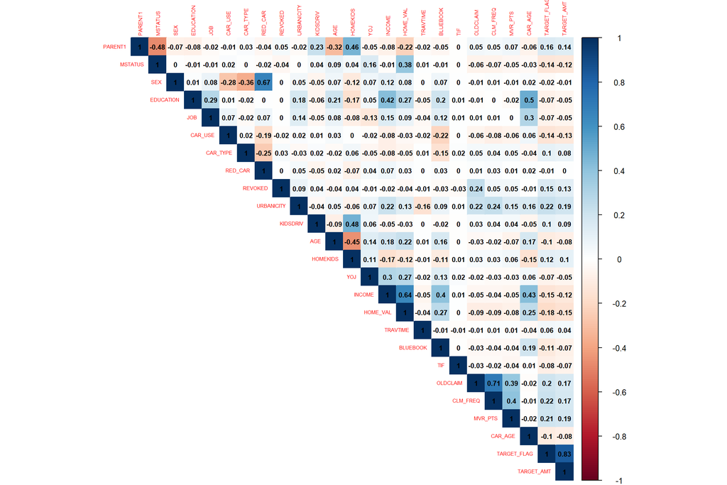

At this point exploration, preparation and pair-wise correlations of **insurance_training_data.csv** are done. So, I’ll begin the same exercise for **insurance-evaluation-data.csv**.

# Data Exploration of insurance-evaluation-data.csv.

Initially, We’ll do a cursory exploration of the data. After that, we’ll iteratively prepare and explore the data, wherever required.

```
## [1] "Dimension of training set:   Number of rows: 2141, Number of cols: 26"
```

```
## [1] "Head of training data set:"
```

```
##   INDEX TARGET_FLAG TARGET_AMT KIDSDRIV AGE HOMEKIDS YOJ  INCOME PARENT1
## 1     3          NA         NA        0  48        0  11 $52,881      No
## 2     9          NA         NA        1  40        1  11 $50,815     Yes
## 3    10          NA         NA        0  44        2  12 $43,486     Yes
## 4    18          NA         NA        0  35        2  NA $21,204     Yes
## 5    21          NA         NA        0  59        0  12 $87,460      No
## 6    30          NA         NA        0  46        0  14              No
##   HOME_VAL MSTATUS SEX     EDUCATION           JOB TRAVTIME    CAR_USE BLUEBOOK
## 1       $0    z_No   M     Bachelors       Manager       26    Private  $21,970
## 2       $0    z_No   M z_High School       Manager       21    Private  $18,930
## 3       $0    z_No z_F z_High School z_Blue Collar       30 Commercial   $5,900
## 4       $0    z_No   M z_High School      Clerical       74    Private   $9,230
## 5       $0    z_No   M z_High School       Manager       45    Private  $15,420
## 6 $207,519     Yes   M     Bachelors  Professional        7 Commercial  $25,660
##   TIF    CAR_TYPE RED_CAR OLDCLAIM CLM_FREQ REVOKED MVR_PTS CAR_AGE
## 1   1         Van     yes       $0        0      No       2      10
## 2   6     Minivan      no   $3,295        1      No       2       1
## 3  10       z_SUV      no       $0        0      No       0      10
## 4   6      Pickup      no       $0        0     Yes       0       4
## 5   1     Minivan     yes  $44,857        2      No       4       1
## 6   1 Panel Truck      no   $2,119        1      No       2      12
##              URBANICITY
## 1   Highly Urban/ Urban
## 2   Highly Urban/ Urban
## 3 z_Highly Rural/ Rural
## 4 z_Highly Rural/ Rural
## 5   Highly Urban/ Urban
## 6   Highly Urban/ Urban
```

```
## [1] "Structure of training data set:"
```

```
## 'data.frame':    2141 obs. of  26 variables:
##  $ INDEX      : int  3 9 10 18 21 30 31 37 39 47 ...
##  $ TARGET_FLAG: logi  NA NA NA NA NA NA ...
##  $ TARGET_AMT : logi  NA NA NA NA NA NA ...
##  $ KIDSDRIV   : int  0 1 0 0 0 0 0 0 2 0 ...
##  $ AGE        : int  48 40 44 35 59 46 60 54 36 50 ...
##  $ HOMEKIDS   : int  0 1 2 2 0 0 0 0 2 0 ...
##  $ YOJ        : int  11 11 12 NA 12 14 12 12 12 8 ...
##  $ INCOME     : chr  "$52,881" "$50,815" "$43,486" "$21,204" ...
##  $ PARENT1    : chr  "No" "Yes" "Yes" "Yes" ...
##  $ HOME_VAL   : chr  "$0" "$0" "$0" "$0" ...
##  $ MSTATUS    : chr  "z_No" "z_No" "z_No" "z_No" ...
##  $ SEX        : chr  "M" "M" "z_F" "M" ...
##  $ EDUCATION  : chr  "Bachelors" "z_High School" "z_High School" "z_High School" ...
##  $ JOB        : chr  "Manager" "Manager" "z_Blue Collar" "Clerical" ...
##  $ TRAVTIME   : int  26 21 30 74 45 7 16 27 5 22 ...
##  $ CAR_USE    : chr  "Private" "Private" "Commercial" "Private" ...
##  $ BLUEBOOK   : chr  "$21,970" "$18,930" "$5,900" "$9,230" ...
##  $ TIF        : int  1 6 10 6 1 1 1 4 4 4 ...
##  $ CAR_TYPE   : chr  "Van" "Minivan" "z_SUV" "Pickup" ...
##  $ RED_CAR    : chr  "yes" "no" "no" "no" ...
##  $ OLDCLAIM   : chr  "$0" "$3,295" "$0" "$0" ...
##  $ CLM_FREQ   : int  0 1 0 0 2 1 0 0 0 0 ...
##  $ REVOKED    : chr  "No" "No" "No" "Yes" ...
##  $ MVR_PTS    : int  2 2 0 0 4 2 0 5 0 3 ...
##  $ CAR_AGE    : int  10 1 10 4 1 12 1 NA 9 1 ...
##  $ URBANICITY : chr  "Highly Urban/ Urban" "Highly Urban/ Urban" "z_Highly Rural/ Rural" "z_Highly Rural/ Rural" ...
```

There are few fields, which have missing values, which we’ll investigate in greater details later.

# Data Preparation of insurance-evaluation-data.csv.

At this stage, We’ll explore and prepare iteratively. First we’ll convert the fields, which are supposed to be numeric, into proper numeric format and strings into string format. After reformatting, we’ll check for NA. After that if required, we’ll impute them.

After that we’ll show some boxplots of the numeric fields.

Checking for NA.

```
## [1] TRUE
```

NA does exist. So, we’ll impute with mice().

Rechecking for NA after imputation.

```
## [1] FALSE
```

We observe that NA were removed in all columns except TARGET_FLAG and TARGET_AMT, which is what we want. In the following, we’ll visualize with missmap().

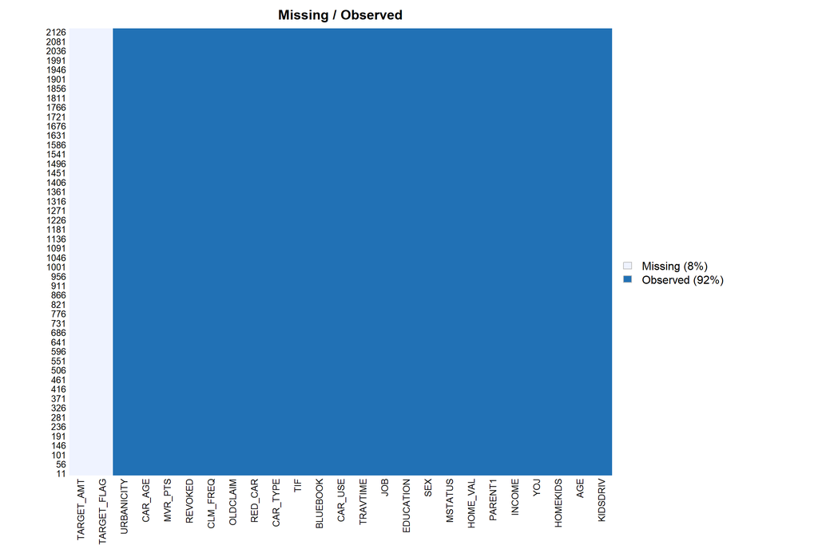

Both is.na() and missmap() confirm that NA were eliminated.

# More Data exploration of insurance-evaluation-data.csv.

Now, we’ll explore the data a little further. First, we’ll take a quick look at min, 1st quartile, median, mean, 2nd quartile, max etc.

|  | TARGET_FLAG | TARGET_AMT | KIDSDRIV | AGE | HOMEKIDS | YOJ | INCOME | PARENT1 | HOME_VAL | MSTATUS | SEX | EDUCATION | JOB | TRAVTIME | CAR_USE | BLUEBOOK | TIF | CAR_TYPE | RED_CAR | OLDCLAIM | CLM_FREQ | REVOKED | MVR_PTS | CAR_AGE | URBANICITY |
| --- | --- | --- | --- | --- | --- | --- | --- | --- | --- | --- | --- | --- | --- | --- | --- | --- | --- | --- | --- | --- | --- | --- | --- | --- | --- |
|  | Min. : NA | Min. : NA | Min. :0.0000 | Min. :17.00 | Min. :0.0000 | Min. : 0.00 | Min. : 0 | Length:2141 | Min. : 0 | Length:2141 | Length:2141 | Length:2141 | Length:2141 | Min. : 5.00 | Length:2141 | Min. : 1500 | Min. : 1.000 | Length:2141 | Length:2141 | Min. : 0 | Min. :0.000 | Length:2141 | Min. : 0.000 | Min. : 0.000 | Length:2141 |
|  | 1st Qu.: NA | 1st Qu.: NA | 1st Qu.:0.0000 | 1st Qu.:39.00 | 1st Qu.:0.0000 | 1st Qu.: 9.00 | 1st Qu.: 25846 | Class :character | 1st Qu.: 0 | Class :character | Class :character | Class :character | Class :character | 1st Qu.: 22.00 | Class :character | 1st Qu.: 8870 | 1st Qu.: 1.000 | Class :character | Class :character | 1st Qu.: 0 | 1st Qu.:0.000 | Class :character | 1st Qu.: 0.000 | 1st Qu.: 1.000 | Class :character |
|  | Median : NA | Median : NA | Median :0.0000 | Median :45.00 | Median :0.0000 | Median :11.00 | Median : 51605 | Mode :character | Median :158830 | Mode :character | Mode :character | Mode :character | Mode :character | Median : 33.00 | Mode :character | Median :14170 | Median : 4.000 | Mode :character | Mode :character | Median : 0 | Median :0.000 | Mode :character | Median : 1.000 | Median : 8.000 | Mode :character |
|  | Mean :NaN | Mean :NaN | Mean :0.1625 | Mean :45.02 | Mean :0.7174 | Mean :10.36 | Mean : 60228 | NA | Mean :152988 | NA | NA | NA | NA | Mean : 33.15 | NA | Mean :15469 | Mean : 5.245 | NA | NA | Mean : 4022 | Mean :0.809 | NA | Mean : 1.766 | Mean : 8.198 | NA |
|  | 3rd Qu.: NA | 3rd Qu.: NA | 3rd Qu.:0.0000 | 3rd Qu.:51.00 | 3rd Qu.:1.0000 | 3rd Qu.:13.00 | 3rd Qu.: 86393 | NA | 3rd Qu.:236449 | NA | NA | NA | NA | 3rd Qu.: 43.00 | NA | 3rd Qu.:21050 | 3rd Qu.: 7.000 | NA | NA | 3rd Qu.: 4718 | 3rd Qu.:2.000 | NA | 3rd Qu.: 3.000 | 3rd Qu.:13.000 | NA |
|  | Max. : NA | Max. : NA | Max. :3.0000 | Max. :73.00 | Max. :5.0000 | Max. :19.00 | Max. :291182 | NA | Max. :669271 | NA | NA | NA | NA | Max. :105.00 | NA | Max. :49940 | Max. :25.000 | NA | NA | Max. :54399 | Max. :5.000 | NA | Max. :12.000 | Max. :26.000 | NA |
|  | NA’s :2141 | NA’s :2141 | NA | NA | NA | NA | NA | NA | NA | NA | NA | NA | NA | NA | NA | NA | NA | NA | NA | NA | NA | NA | NA | NA | NA |

## Data reordering

For downstream analysis, we’ll reorder the columns into categorical, numeric and target.

## Boxplots

Let’s take a first look at the boxplots

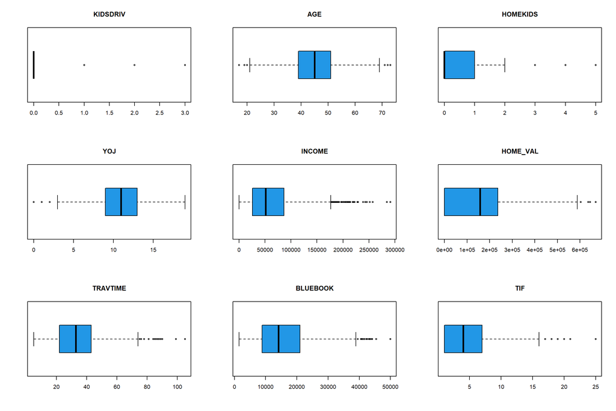

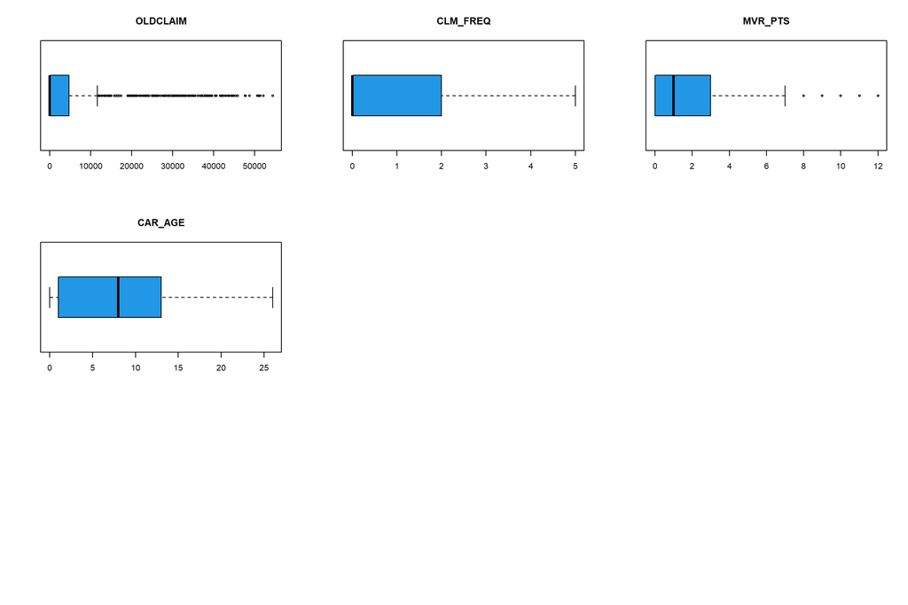

The boxplots show that some of the variables have outliers in them. So, we’ll cap them.

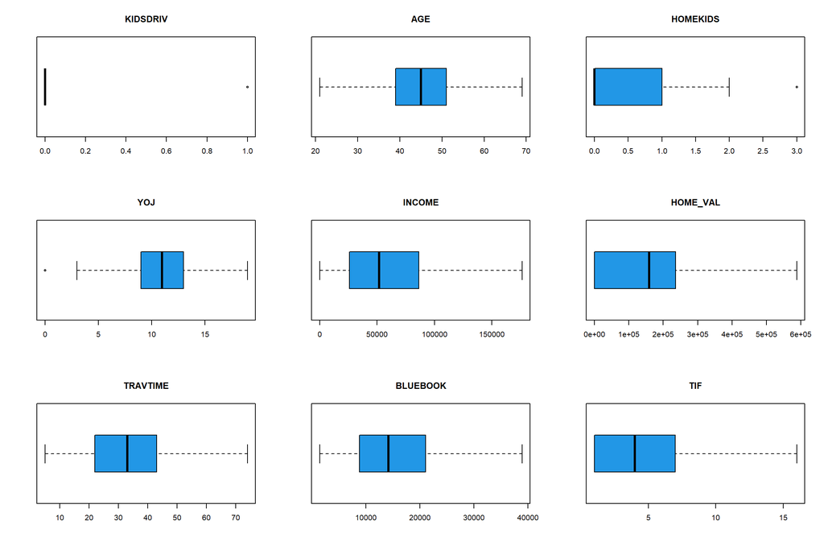

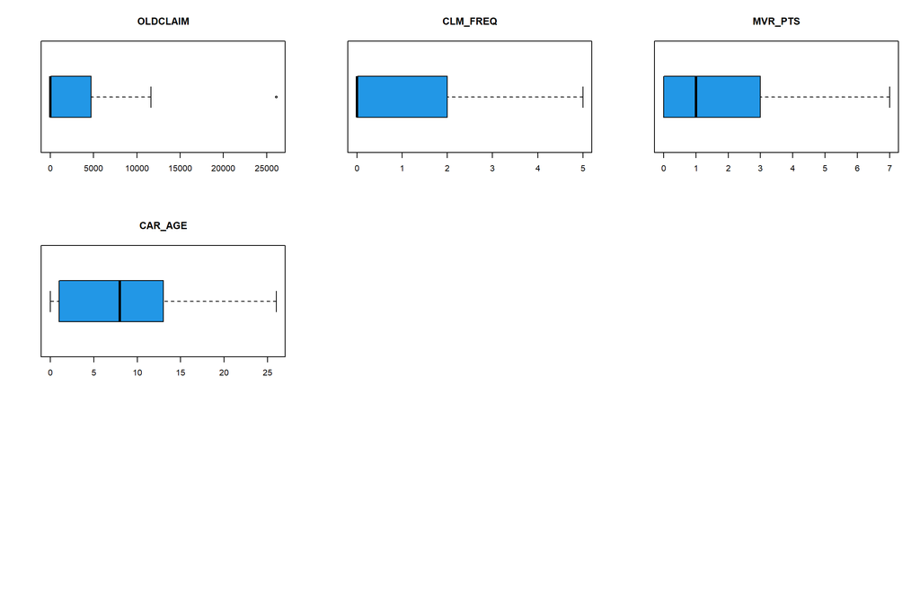

The fields AGE, HOMEKIDS, INCOME, HOME_VAL, TRVTIME, BLUEBOOK, TIF, CLM_FREQ, MVR_PTS, CAR_AGE have higher variance.

Let’s ignore the boxplots for TARGET_FLAG and TARGET_AMT.

## Histograms

Histograms tell us how the data is distributed in the dataset (numeric fields).

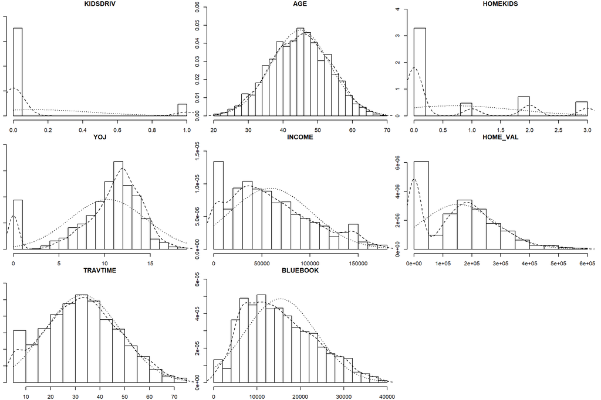

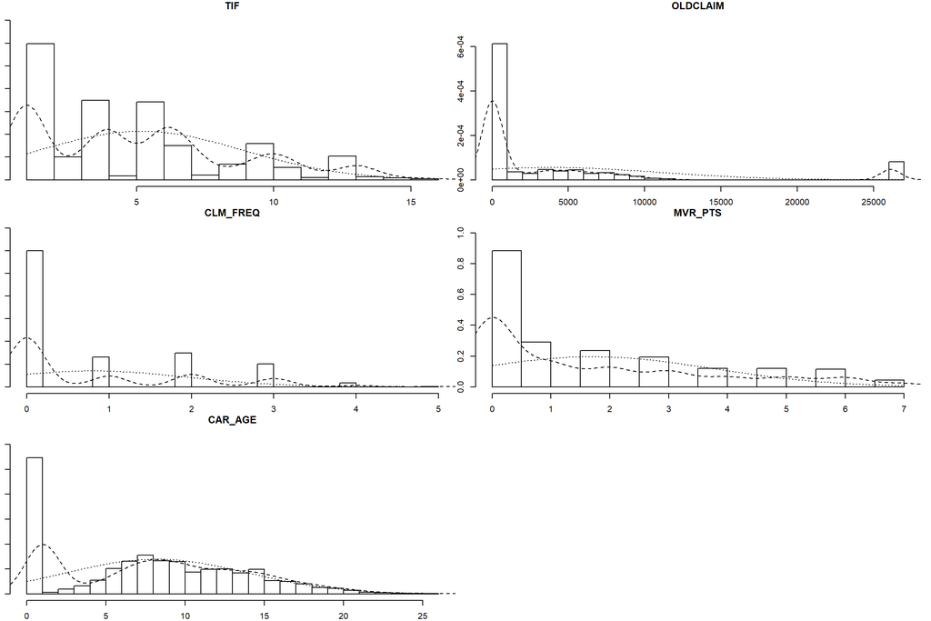

## Categorical variables

Now, we’ll explore the Categorical variables.

```
## PARENT1:
```

```
##
##   No  Yes
## 1875  266
```

```
## MSTATUS:
```

```
##
##   No  Yes
##  847 1294
```

```
## SEX:
```

```
##
##    F    M
## 1170  971
```

```
## EDUCATION:
```

```
##
## <High School    Bachelors  High School      Masters          PhD
##          312          581          622          420          206
```

```
## JOB:
```

```
##
##               Blue Collar     Clerical       Doctor   Home Maker       Lawyer
##          139          463          319           75          202          196
##      Manager Professional      Student
##          269          291          187
```

```
## CAR_USE:
```

```
##
## Commercial    Private
##        760       1381
```

```
## CAR_TYPE:
```

```
##
##     Minivan Panel Truck      Pickup  Sports Car         SUV         Van
##         549         177         383         272         589         171
```

```
## RED_CAR:
```

```
##
##   no  yes
## 1543  598
```

```
## REVOKED:
```

```
##
##   No  Yes
## 1880  261
```

```
## URBANICITY:
```

```
##
## Highly Rural/ Rural Highly Urban/ Urban
##                 403                1738
```

Observation: In JOB columns, 139 rows are empty. So, we’ have to’ll impute them with “Unknown”.

```
## JOB:
```

```
##
##  Blue Collar     Clerical       Doctor   Home Maker       Lawyer      Manager
##          463          319           75          202          196          269
## Professional      Student      Unknown
##          291          187          139
```

## Correlations.

At this point the data is prepared. So, we’ll explore the top correlated variables.

There are 25 variables, among which 15 are numeric and 10 are non-categorical. In order to find pai-wise correlations, we’ll give numerical values to the correlated variables.

Now, we’ll look at the correlation matrix of the variables.

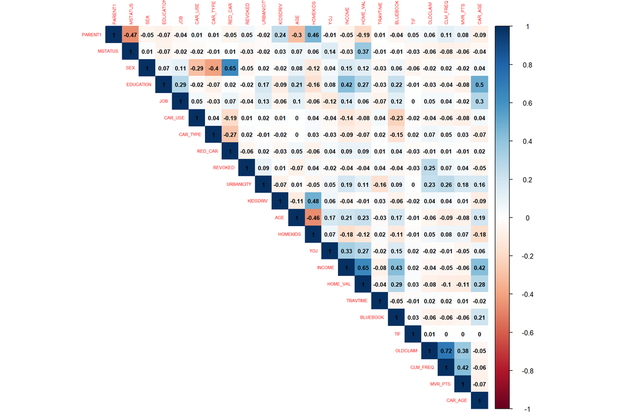

At this point exploration, preparation and pair-wise correlations of insurance_evaluation_data.csv are done. So, We’ll begin the model building process.

# Building Models

Now, we are ready to build models. We will build model using **insurance_training_data.csv** and compare the models. Then we will use the best model to predict on **insurance-evaluation-data.csv**

Our task is to classify the TARGET_FLAG variable using logistic regression and predict the value of TARGET_AMT using Linear Regression.

We split Ins_train_cap_imputed into training and test in 80/20 ratio and named as **Ins_train_cap_imputed_trn** and **Ins_train_cap_imputed_tst**.